# Tutorial: Approximate Methods

### Optimal summary statistics

Depending on what summaries we decided to use above, the previous section's ABC may have worked extremely poorly. If so, this hopefully impresses on you the importance of thinking these decisions through. If not, have a look at the web version of this solved notebook to see how a deliberately poor choice works out.

Either way, we will now run an ABC using the optimal summary statistics for this particular problem, which are the OLS estimators of $a$ and $b$ (surprise!). We will not change the distance function initially.

In code, we can derive a new class from `ABS_ours` (which has appropriate `distance` and `simulate` methods already), and overload (i.e. replace) only the `summaries` method.

```python
# class ABC_OLS(ABC_ours):
#     def summaries(self, x, y):
#         # return summary statistics, the OLS estimators of a and b, as a 1D np.array

abc1 = ABC_OLS(x, y, priors)
```

As a quick check, this object should give us back the OLS estimators we got at the beginning of the notebook if we run `summaries` on the real data.

```python
assert all(ols.params == abc1.summaries(x,y))
```

Let's run and see how these results converge as the threshold is reduced.

```python
%time abc1.run(20000)
```

```
CPU times: user 11.7 s, sys: 44.4 ms, total: 11.7 s
Wall time: 11.8 s
```

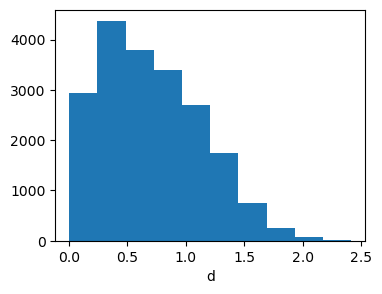

```python
abc1.distance_hist();
```

```
eps = 0.6545126265864643
Acceptance rate: 0.5 ( 10000 accepted samples )
```

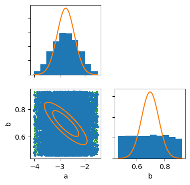

```python
eps = np.quantile(abc1.distances, 0.5)
print("eps =", eps)
abc1.select_distances(eps)
abc1.plot_acceptances(truth=true_post, size=4.0)
```

```
eps = 0.19439434899714933
Acceptance rate: 0.1 ( 2000 accepted samples )
```

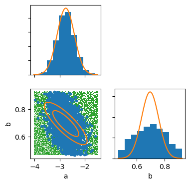

```python
eps = np.quantile(abc1.distances, 0.1)
print("eps =", eps)
abc1.select_distances(eps)
abc1.plot_acceptances(truth=true_post, size=4.0)
```

```
eps = 0.1347688101494705
Acceptance rate: 0.05 ( 1000 accepted samples )
```

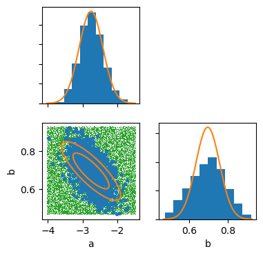

```python
eps = np.quantile(abc1.distances, 0.05)
print("eps =", eps)
abc1.select_distances(eps)
abc1.plot_acceptances(truth=true_post, size=4.0)
```

```
eps = 0.05867312084143261
Acceptance rate: 0.01 ( 200 accepted samples )
```

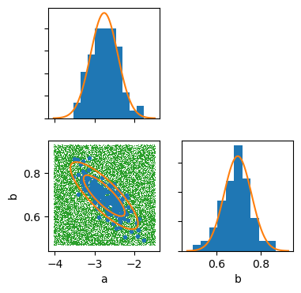

```python
eps = np.quantile(abc1.distances, 0.01)
print("eps =", eps)
abc1.select_distances(eps)
abc1.plot_acceptances(truth=true_post, size=4.0)
```

Unless we've chosen a particularly strange distance function, you should see the ABC samples converging to the truth, but not equally quickly in both parameters. We can do better than this! If we have a guess of the width of the posterior in each parameter, it would make sense to incorporate those scales into the distance function. That is, we could redefine the distance such that

$d(\Delta \hat{a}, \Delta \hat{b}) \rightarrow d\left(\frac{\Delta\hat{a}}{\sigma_a}, \frac{\Delta\hat{b}}{\sigma_b}\right)$.

Here $\hat{a}$ and $\hat{b}$ are our summary statistics, and $\sigma_a$ and $\sigma_b$ are estimates of the width of the posterior in each parameter (the marginalized standard deviations of our posterior estimate). Even better would be to use the 2D covariance estimate, but this simpler modification will suffice (not to mention, we're already using a lot of information we might not have in general).

Put this modification into code by deriving a new class inheriting from `ABC_OLS` and overloading the `distances` method.

```python
# class ABC_OLS2(ABC_OLS):
#     def distance(self, s1, s2):
#         # return scalar distance between 2 sets of summary statistics

abc2 = ABC_OLS2(x, y, priors)
```

Quick check for crashes:

```python
abc2.run(1)
```

Again, let's produce a bunch of samples and see how the convergence looks as the distance threshold is reduced.

```python
%time abc2.run(20000)
```

```
CPU times: user 11.5 s, sys: 45.5 ms, total: 11.5 s
Wall time: 11.5 s
```

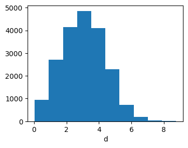

```python
abc2.distance_hist();
```

```
eps = 3.057937865615461
Acceptance rate: 0.5 ( 10000 accepted samples )
```

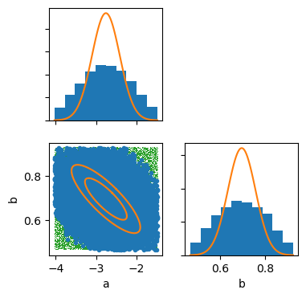

```python
eps = np.quantile(abc2.distances, 0.5)
print("eps =", eps)
abc2.select_distances(eps)
abc2.plot_acceptances(truth=true_post, size=4.0)
```

```
eps = 1.3243872565570287
Acceptance rate: 0.1 ( 2000 accepted samples )
```

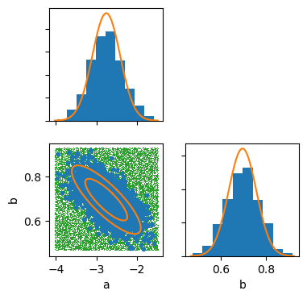

```python
eps = np.quantile(abc2.distances, 0.1)
print("eps =", eps)
abc2.select_distances(eps)
abc2.plot_acceptances(truth=true_post, size=4.0)
```

```
eps = 0.9501546177624834
Acceptance rate: 0.05 ( 1000 accepted samples )
```

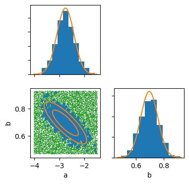

```python
eps = np.quantile(abc2.distances, 0.05)
print("eps =", eps)
abc2.select_distances(eps)
abc2.plot_acceptances(truth=true_post, size=4.0)
```

```
eps = 0.4210760671844682
Acceptance rate: 0.01 ( 200 accepted samples )
```

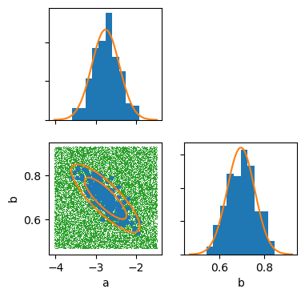

```python
eps = np.quantile(abc2.distances, 0.01)
print("eps =", eps)
abc2.select_distances(eps)
abc2.plot_acceptances(truth=true_post, size=4.0)
```

You should now see a progression that plausibly looks like it's smoothly approaching the true posterior.

```python
Yes_I_totally_see_that = False # change to True when true
```

```python
assert Yes_I_totally_see_that
```

## Case: linear model with unknown scatter

Now that you have some experience with the nuts and bolts of LA and ABC, we'll apply them to a situation that's only slightly more complex, but doesn't have a pretty exact solution. Namely,

- We have data in the form of a list of $(x,y)$ pairs.
- The $x$ values are fixed (we assume no uncertainty in their generation).
- Each $y$ values is independently generated from a linear model: $y_i = a + b x_i + \varepsilon_i$, where $\varepsilon_i$ follows the a normal distribution with zero mean and unknown variance, $\sigma^2$, that we will fit for.
- Priors on $a$ and $b$ are both uniform over the real line; the prior on $\sigma^2$ is uniform over non-negative values.

Comparing with above, the key difference here is that the scatter of $y$ about the linear model is a free parameter that we will fit for, in addition to the slope and intercept.

```python
param_names2 = param_names + ['s2']
```

As always, draw and write down the generative model.

> Space for the generative model

To keep things from being too boring, we will read in a second data set for which $\sigma^2 \neq 1$.

```python
table2 = np.loadtxt(datapath+'data2.txt')
x2 = table2[:,0]
y2 = table2[:,1]
```

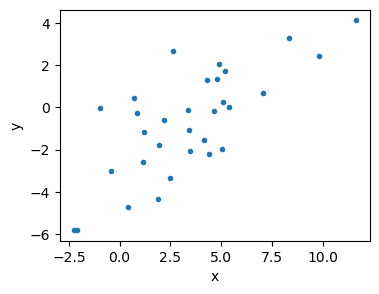

```python
plt.rcParams['figure.figsize'] = (4.0, 3.0)
plt.plot(x2, y2, '.');
plt.xlabel("x"); plt.ylabel("y");
```

While there isn't a simple exact solution for this scenario, it would still be nice to compare to a solution we're confident in. Fortunately, this model, for data like those we're using, is easily handled with conjugate Gibbs sampling. So we'll do that quickly before moving on.

We are extremely confident that `LRGS` can handle this problem without oversight, but since your data are randomly generated there is no 100% guarantee. If things look weird below and you want to look closer, the commented cell below will show the traces. Without further commentary,

```python
par = lrgs.Parameters(np.matrix([x2]).T, np.matrix([y2]).T, M_inv=[np.asmatrix(np.zeros(2)) for i in range(len(x2))], Sigma_prior=(-2., np.matrix(np.zeros((1,1)))))
```

```python
chain = lrgs.Chain(par, 15000)
```

```python
%time chain.run(fix='y') # <10s on an old laptop
```

```
CPU times: user 9.26 s, sys: 80 ms, total: 9.34 s
Wall time: 9.47 s
```

```python
chdict = chain.to_dict(['B','Sigma'])
charr = np.array([chdict[p] for p in ['B_0_0','B_1_0','Sigma_0_0']]).T
```

```python
#plt.rcParams['figure.figsize'] = (12.0, 2.0*len(param_names2))
#fig, ax = plt.subplots(len(param_names2), 1);
#cr.plot_traces(charr, ax, labels=param_names2);
```

```python
charr = charr[10:,:]
tri = cr.whist_triangle(charr, bins=50, smooth2D=1);
```

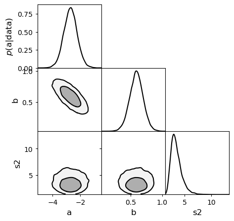

```python
cr.whist_triangle_plot(tri, paramNames=param_names2);
```

### Laplace Approximation

Now that we hopefully have a reliable posterior from MCMC to compare to, let's try the LA for this problem. As before, write a function to return minus the log-posterior:

```python
def minus_lnp2(params, x, y):
    # return -ln(posterior) given params, a 1D np.array [a,b,s2]
```

Again, a very crude guess should work for us.

```python
guess2 = [0.0, 0.0, 1.0]
```

Find the posterior maximum! Note that we need to use the `bounds` argument so that `minimize` knows that the `s2` parameter may not be negative. This causes it to internally choose a different algorithm than it would have used by default otherwise, with the upshot that we need to do something slightly different to access the inverse-Hessian (see below).

```python
LA2 = minimize(minus_lnp2, guess2, bounds=[(None,None), (None,None), (0.0,None)], args=(x2, y2))
LA2
```

```
  message: CONVERGENCE: NORM_OF_PROJECTED_GRADIENT_<=_PGTOL
  success: True
   status: 0
      fun: 59.8988630297158
        x: [-2.718e+00  5.945e-01  2.791e+00]
      nit: 15
      jac: [ 7.105e-07  0.000e+00 -7.105e-07]
     nfev: 72
     njev: 18
 hess_inv: <3x3 LbfgsInvHessProduct with dtype=float64>
```

```python
LA2_mean = LA2.x
LA2_cov = LA2.hess_inv.todense()
print("mean:", LA2_mean)
print("cov:", LA2_cov)
```

```
mean: [-2.71795238  0.59450388  2.7914622 ]
cov: [[ 0.19321949 -0.0404238  -0.05339119]
 [-0.0404238   0.02055936  0.05755932]
 [-0.05339119  0.05755932  0.80633199]]
```

The cell below will compare the LA (red/dashed curves) with our MCMC posterior (blue/solid curves):

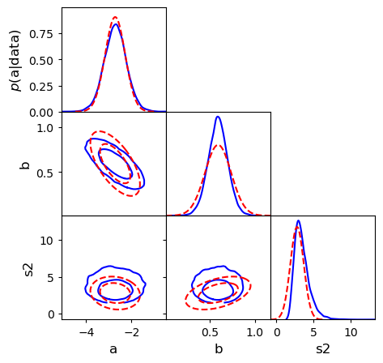

```python
fig,ax = cr.whist_triangle_plot(tri, paramNames=param_names2, linecolor1D='b', linecolor2D='b', fill2D=False);
for i,p in enumerate(param_names2):
    aa = np.linspace(LA2_mean[i]-4*np.sqrt(LA2_cov[i,i]), LA2_mean[i]+4*np.sqrt(LA2_cov[i,i]), 100)
    ax[i][i].plot(aa, st.norm.pdf(aa, LA2_mean[i], np.sqrt(LA2_cov[i,i])), '--', color='r');
    ax[i][i].set_xlim(min(ax[i][i].get_xlim()[0], LA2_mean[i]-4*np.sqrt(LA2_cov[i,i])), max(ax[i][i].get_xlim()[1], LA2_mean[i]+4*np.sqrt(LA2_cov[i,i])))
    ax[i][i].set_ylim(0.0, max(ax[i][i].get_ylim()[1], st.norm.pdf(aa, LA2_mean[i], np.sqrt(LA2_cov[i,i])).max()*1.1))
    for j,q in enumerate(param_names2):
        if i==j:
            break
        cr.cov_ellipse(LA2_cov[np.ix_([j,i],[j,i])], center=LA2_mean[[j,i]], level=0.68268949, plot=ax[i][j], fmt='--', color='r')
        cr.cov_ellipse(LA2_cov[np.ix_([j,i],[j,i])], center=LA2_mean[[j,i]], level=0.95449974, plot=ax[i][j], fmt='--', color='r')
        ax[i][j].set_xlim(min(ax[i][j].get_xlim()[0], LA2_mean[j]-4*np.sqrt(LA2_cov[j,j])), max(ax[i][j].get_xlim()[1], LA2_mean[j]+4*np.sqrt(LA2_cov[j,j])))
        ax[i][j].set_ylim(min(ax[i][j].get_ylim()[0], LA2_mean[i]-4*np.sqrt(LA2_cov[i,i])), max(ax[i][j].get_ylim()[1], LA2_mean[i]+4*np.sqrt(LA2_cov[i,i])))
```

For our data, the LA gets close to the posterior mode, but its estimate of the covariance leaves something to be desired. Note that, for this setup, we have found something of a phase change when the data set gets small enough that the scatter is tough to distinguish from zero - LA's covariance in that case suddenly becomes much larger. For bigger data sets that the one here, the approximation, including the covariance, gets better. We've deliberately aimed in the middle for this demonstration, which is to say that you might see any of this behaviour in your own, random data sets. (It's also possible that some of this is due to the specific way the Hessian is estimated within `minimize`, and a more careful estimate of the second derivatives would do better; we haven't investigated.)

### Approximate Bayes

As before, let's functionally redefine the range of our priors based on what you see above. In real life, you can imagine doing this based on the LA in the first place, and iterating if you see the resulting approximate posterior doesn't become tiny before hitting the edge of the prior. We won't mind if you cheat a little and use the MCMC result to motivate the refined priors in this case, but keep in mind that they should include at least the entire volume of parameter space where the chain has samples.

```python
# priors2 = {'a':..., 'b':..., 's2':...}
```

What summary statistics and distance function would you use for this problem? **Note: in class we will reach a consensus for what to implement below.**

```python
# class ABC_scat(ABC):
#     def summaries(self, x, y):
#         # return summary statistics as a 1D np.array
#     def distance(self, s1, s2):
#         # return scalar distance between 2 sets of summary statistics
#     def simulate(self, a=0.0, b=0.0, s2=1.0):
#         # return a simulated 1D array y, given self.x and additional parameters arguments (with default values)

abc3 = ABC_scat(x2, y2, priors2)
```

As always, we next check for obvious code bugs:

```python
abc3.run(1)
print(abc3.samples)
print(abc3.distances)
```

```
[[-2.94627433  0.86675959 12.19002481]]
[9.7587713]
```

Given the additional free parameter, we expect to need to run for longer to get a useful number of accepted samples.

```python
%time abc3.run(20000)
```

```
CPU times: user 15.1 s, sys: 95.3 ms, total: 15.2 s
Wall time: 15.5 s
```

Let's see what that gave us:

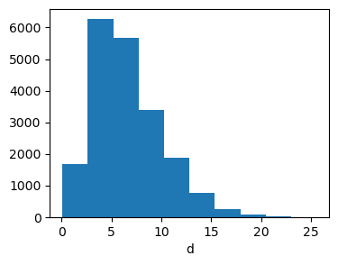

```python
abc3.distance_hist();
```

```
eps = 5.974735324540064
Acceptance rate: 0.5 ( 10000 accepted samples )
```

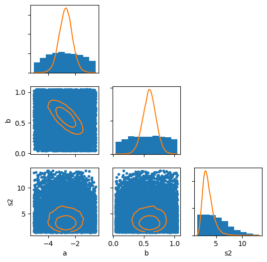

```python
eps = np.quantile(abc3.distances, 0.5)
print("eps =", eps)
abc3.select_distances(eps)
abc3.plot_acceptances(truth_tri=tri, size=6.0, show_rejects=False)
```

```
eps = 2.8341680811343344
Acceptance rate: 0.1 ( 2000 accepted samples )
```

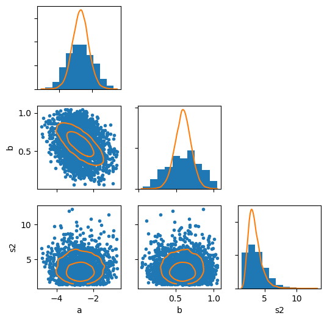

```python
eps = np.quantile(abc3.distances, 0.1)
print("eps =", eps)
abc3.select_distances(eps)
abc3.plot_acceptances(truth_tri=tri, size=6.0, show_rejects=False)
```

```
eps = 2.183490628701815
Acceptance rate: 0.05 ( 1000 accepted samples )
```

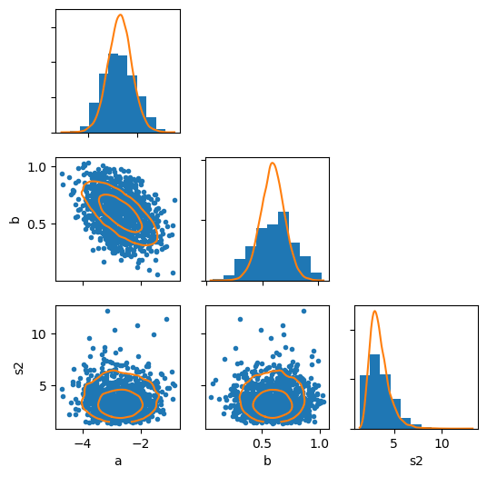

```python
eps = np.quantile(abc3.distances, 0.05)
print("eps =", eps)
abc3.select_distances(eps)
abc3.plot_acceptances(truth_tri=tri, size=6.0, show_rejects=False)
```

```
eps = 1.2939580058803228
Acceptance rate: 0.01 ( 200 accepted samples )
```

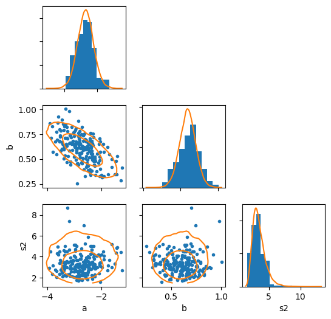

```python
eps = np.quantile(abc3.distances, 0.01)
print("eps =", eps)
abc3.select_distances(eps)
abc3.plot_acceptances(truth_tri=tri, size=6.0, show_rejects=False)
```

Hopefully you can see indications that ABC is working, although chances are you would also need to run longer and decrease the acceptance threshold even more before the comparison to the MCMC results really starts to look good. We stress that there are more intelligent, adaptive implementations of ABC than our simplistic version, which one would turn to in practice.

```python
Yes_this_all_checks_out = False # change to True when true
```

```python
assert Yes_this_all_checks_out
```

### Bootstrap

We conclude this notebook with a quick implementation of the bootstrap. Recall that this is a frequentist method for "robustly" estimating uncertainties in estimates when the sampling distribution is not well known enough to do maximum likelihood (for example). The procedure is

- randomly sample from the data with replacement,
- compute the estimator(s) from the sampled data,
- repeat many times, and look at the distribution of estimates.

Let's go ahead and do this using the summary statistics from the above exercise (with free scatter) as our estimators. In this context, to be clear, resampling the data means resampling the *pairs* $(x,y)$, not sampling $x$s and $y$s independently.

Below, complete a function that resamples the given data and returns it in a tuple. (This hardly seems worth making an exercise, which says something about the simplicity of implementing the bootstrap.)

```python
def bootstrap(x, y):
    # i = list of indices into x and y encoding the resampling; see np.random.choice
    return x[i],y[i]
```

Let's run it...

```python
%%time
boot = np.full((20000,3), np.nan)
for i in range(boot.shape[0]):
    xb,yb = bootstrap(x2, y2)
    boot[i,:] = abc3.summaries(xb, yb)
```

```
CPU times: user 9.47 s, sys: 56.3 ms, total: 9.53 s
Wall time: 9.77 s
```

... and compare to the MCMC posterior for this problem. Below, the bootstrap distribution is red/dashed curves, and the MCMC posterior is blue/solid.

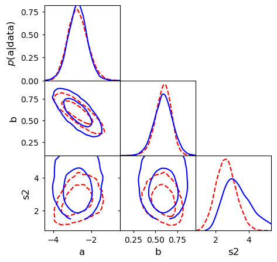

```python
boot_tri = cr.whist_triangle(boot, bins=50, smooth2D=1);
fig,ax = cr.whist_triangle_plot(boot_tri, paramNames=param_names2, linecolor1D='r', linecolor2D='r', linestyle1D='--', linestyle2D='--', fill2D=False);
cr.whist_triangle_plot(tri, linecolor1D='b', linecolor2D='b', fill2D=False, axes=ax);
```

## Parting thoughts

We hope you have gained an appreciation for and understanding of some of the approximate methods covered in the notes. Possibly, you're now more motivated to avoid using them whenever possible. Still, while a little ingenuity can go a long way in making MCMC and related methods more tractable, it's nice to know that there are approximate methods that still live in the realm of principled inference.